# Self evaluation

This is a traning for the final exam

Consider the data set *mtcars*, loaded by

```r
data(mtcars)
```

The data was extracted from the 1974 Motor Trend US magazine, and comprises fuel consumption and 10 aspects of automobile design and performance for 32 automobiles (1973–74 models). For each car the data-set contains the following variables:

- *mpg* Miles/(US) gallon
- *cyl* Number of cylinders
- *disp* Displacement (cu.in.)
- *hp* Gross horsepower
- *drat* Rear axle ratio
- *wt* Weight (1000 lbs)
- *qsec* 1/4 mile time
- *vs* V/S
- *am* Transmission (0 = automatic, 1 = manual)
- *gear* Number of forward gears - carb Number of carburetors
1. Compute *mean*, *median* and *sd* for each variable

```r
# your code goes here

summary_stats <- data.frame(
  Variable = colnames(mtcars),
  Mean = sapply(mtcars, mean),
  Median = sapply(mtcars, median),
  SD = sapply(mtcars, sd)
)

print(summary_stats)
```

```
     Variable       Mean  Median          SD
mpg       mpg  20.090625  19.200   6.0269481
cyl       cyl   6.187500   6.000   1.7859216
disp     disp 230.721875 196.300 123.9386938
hp         hp 146.687500 123.000  68.5628685
drat     drat   3.596563   3.695   0.5346787
wt         wt   3.217250   3.325   0.9784574
qsec     qsec  17.848750  17.710   1.7869432
vs         vs   0.437500   0.000   0.5040161
am         am   0.406250   0.000   0.4989909
gear     gear   3.687500   4.000   0.7378041
carb     carb   2.812500   2.000   1.6152000
```

2. Create a scatterplot of *Displacement* versus *Gross horsepower*, can we see any relation between these variables?

From the graph below we can observe a positive correlation between displacement and horsepower as both are increasing

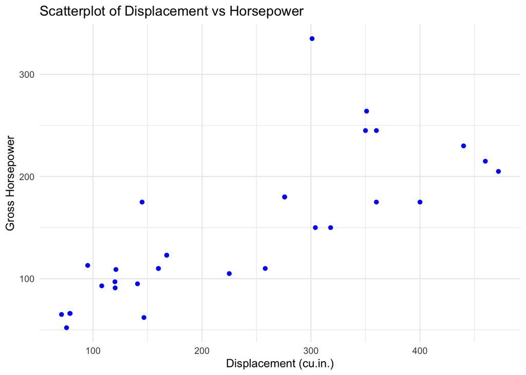

```r
# your code goes here
library(ggplot2)

ggplot(mtcars, aes(x = disp, y = hp)) +
  geom_point(color = "blue") +
  labs(title = "Scatterplot of Displacement vs Horsepower",
       x = "Displacement (cu.in.)",
       y = "Gross Horsepower") +
  theme_minimal()
```

3. Compute the *correlation coefficient* between these two variable. Does it support the idea you had by looking at the scatterplot?

The coefficient being 0.791 indicates it is strongly positive as evident in the scatter graph above being directly proportional

```r
# your code goes here

correlation <- cor(mtcars$disp, mtcars$hp)
print(correlation)
```

```
[1] 0.7909486
```

4. Run a PCA. How many dimensions would you retain? look at the eigenvalues by using the *fviz_screeplot* function from the *factoextra* package

Here we find that the first two pca explains 84% of the variance. We should retain these two as they have eigenvalue higher than 1

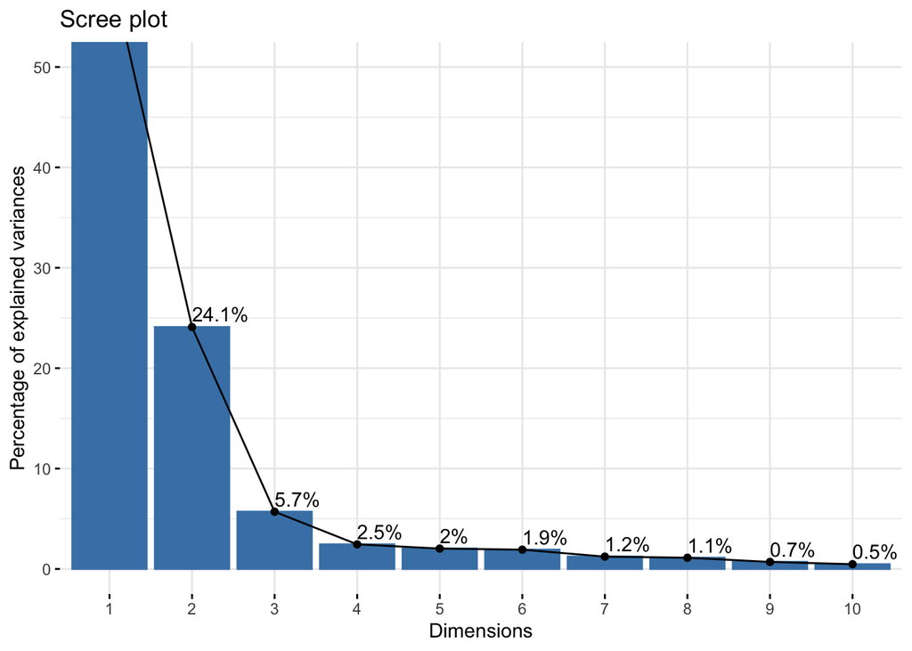

```r
# your code goes here
pca_result <- PCA(mtcars, scale.unit = TRUE, graph = FALSE)
fviz_screeplot(pca_result, addlabels = TRUE, ylim = c(0, 50))
```

```r
pca_result$eig
```

```
        eigenvalue percentage of variance cumulative percentage of variance
comp 1  6.60840025             60.0763659                          60.07637
comp 2  2.65046789             24.0951627                          84.17153
comp 3  0.62719727              5.7017934                          89.87332
comp 4  0.26959744              2.4508858                          92.32421
comp 5  0.22345110              2.0313737                          94.35558
comp 6  0.21159612              1.9236011                          96.27918
comp 7  0.13526199              1.2296544                          97.50884
comp 8  0.12290143              1.1172858                          98.62612
comp 9  0.07704665              0.7004241                          99.32655
comp 10 0.05203544              0.4730495                          99.79960
comp 11 0.02204441              0.2004037                         100.00000
```

6. Plot the variables by controlling for their contributions (tips use the *col.var* option in the *fviz_pca_var* function)

Displacement (disp), horsepower (hp), no of cylinder (cyl) and weight are positively correlated and close suggesting that heavier cars tend to have more cylinders, larger engine displacement, and higher horsepower.

The mpg (fuel efficiency) arrow points opposite to hp (horsepower) and wt (weight), indicating a strong negative correlation suggesting that cars with higher horsepower and weight tend to have lower fuel efficiency (mpg).

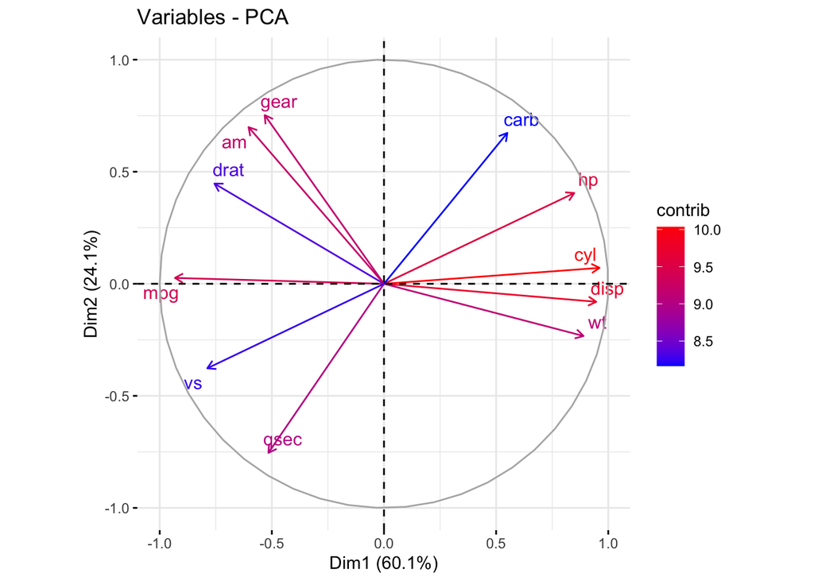

```r
# your code goes here
fviz_pca_var(pca_result,
             col.var = "contrib",
             gradient.cols = c("blue", "red"),
             repel = TRUE)
```

7. Produce a plot to display cars, showing the top 10 in terms of contribution to the first and to the second axis.

We can find that Honda Civic and Toyota Corolla contribute the most and have the strongest influence on the axis. Luxury and larger cars also contribute significantly

Maserati Bora has the highest contribution and Ford Pantera L and Ferrari Dino also contribute significantly

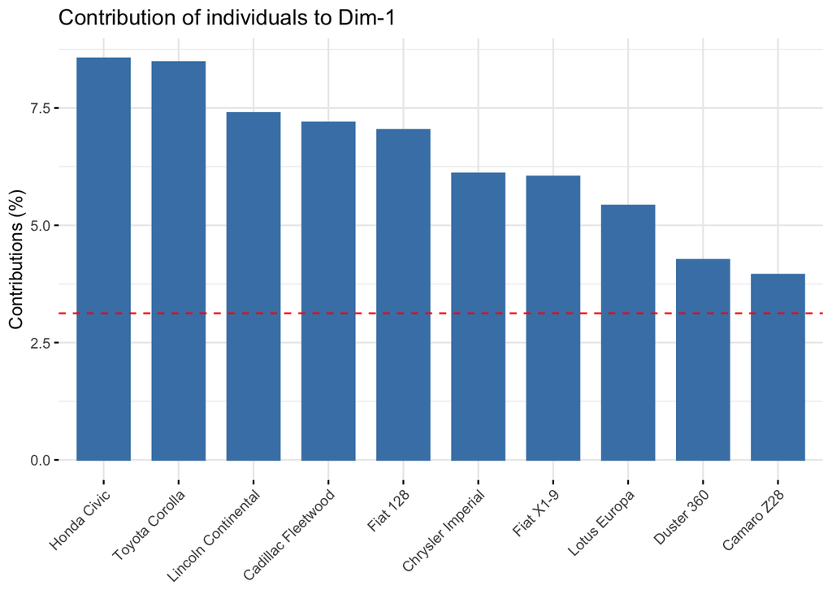

```r
# your code goes here
fviz_contrib(pca_result, choice = "ind", axes = 1, top = 10)
```

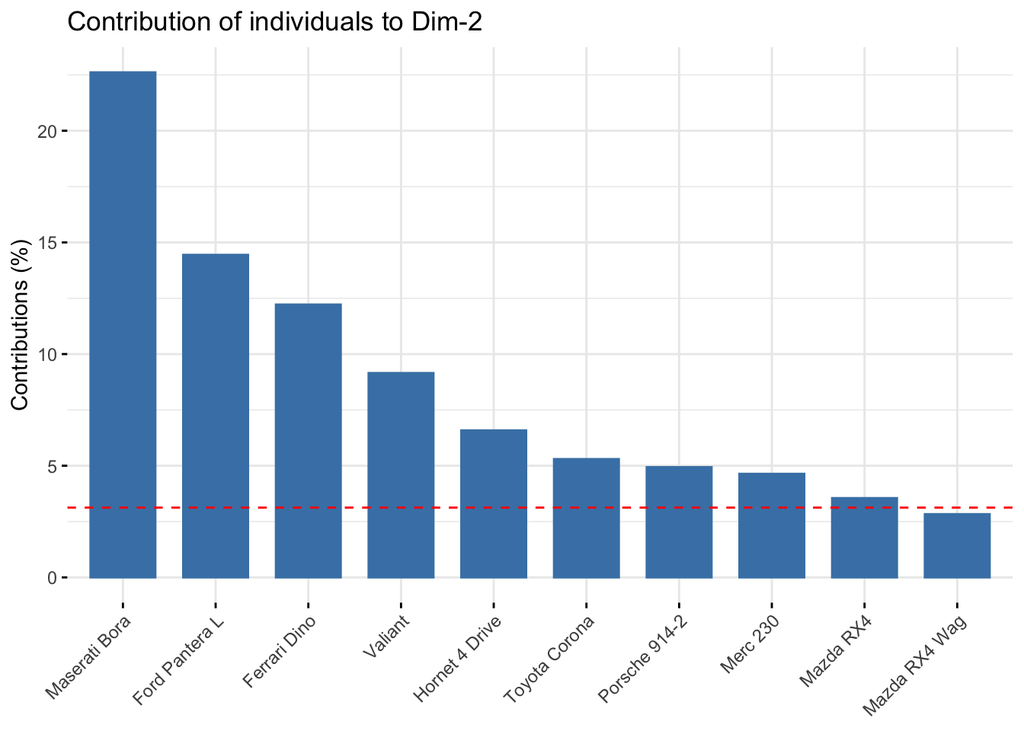

```r
fviz_contrib(pca_result, choice = "ind", axes = 2, top = 10)
```